# Miltary coup

ChiratchayaJanpechpanao

## Introduction

This project examines how political and demographic factors are related to the number of successful military coups in sub-Saharan Africa. Variables considered include years of military oligarchy, number of political parties, population size, number of elections, regime duration, and country size. All analyses were conducted using R Studio.

# Initial Data Analysis

The dataset contains 47 observations and 9 variables describing political and demographic characteristics across countries. The variables fall into two main groups:

Factor variables:

miltcoup: Number of successful military coups from independence to 1989 numregim: Number of regime types parties: Number of legal political parties in 1993 oligarchy: Number of years the country was ruled by a military oligarchy from independence to 1989 numelec: Total number of legislative and presidential elections Numeric variables: popn: Population (in millions) in 1989 size: Land area in thousand square kilometers A quick inspection shows that the variable Pollib contains 5 missing values, while pctovote has 6 missing values, which will need to be addressed before conducting further analysis.

Key Points: Exploring the data visually and statistically helps detect relationships between variables. Single-variable models show that the duration of oligarchy has the strongest influence on coups.

```r
library(faraway)
library(esquisse)
```

```r
library(ggplot2)
library(AER)
library(MASS)
library(corrplot)
library(GGally)
data(africa)
str(africa)
```

```
## 'data.frame':    47 obs. of  9 variables:
##  $ miltcoup : int  0 5 0 6 2 0 1 3 1 2 ...
##  $ oligarchy: int  0 7 0 13 13 0 0 14 15 0 ...
##  $ pollib   : int  2 1 NA 2 2 2 2 2 2 2 ...
##  $ parties  : int  38 34 7 62 10 34 5 14 27 4 ...
##  $ pctvote  : num  NA 45.7 20.3 17.5 34.4 ...
##  $ popn     : num  9.7 4.6 1.2 8.8 5.3 11.6 0.361 3 5.5 0.458 ...
##  $ size     : num  1247 113 582 274 28 ...
##  $ numelec  : int  0 8 5 5 3 14 2 6 4 6 ...
##  $ numregim : int  1 3 1 3 3 3 1 4 3 2 ...
```

```r
summary(africa)
```

```
##     miltcoup       oligarchy          pollib         parties
##  Min.   :0.000   Min.   : 0.000   Min.   :0.000   Min.   : 0.00
##  1st Qu.:0.000   1st Qu.: 0.000   1st Qu.:1.000   1st Qu.:10.00
##  Median :1.000   Median : 1.000   Median :2.000   Median :13.00
##  Mean   :1.404   Mean   : 4.447   Mean   :1.667   Mean   :15.96
##  3rd Qu.:2.000   3rd Qu.: 9.000   3rd Qu.:2.000   3rd Qu.:19.00
##  Max.   :6.000   Max.   :18.000   Max.   :2.000   Max.   :62.00
##                                   NA's   :5
##     pctvote           popn              size           numelec
##  Min.   : 0.00   Min.   :  0.067   Min.   :   0.5   Min.   : 0.000
##  1st Qu.:18.90   1st Qu.:  1.450   1st Qu.:  33.0   1st Qu.: 4.000
##  Median :28.95   Median :  5.600   Median : 274.0   Median : 6.000
##  Mean   :31.88   Mean   : 10.953   Mean   : 516.7   Mean   : 6.191
##  3rd Qu.:43.04   3rd Qu.: 11.450   3rd Qu.: 813.0   3rd Qu.: 8.500
##  Max.   :77.40   Max.   :113.800   Max.   :2506.0   Max.   :14.000
##  NA's   :6
##     numregim
##  Min.   :1.000
##  1st Qu.:2.000
##  Median :3.000
##  Mean   :2.511
##  3rd Qu.:3.000
##  Max.   :4.000
##
```

```r
sort(africa$miltcoup)  #18 nollor
```

```
##  [1] 0 0 0 0 0 0 0 0 0 0 0 0 0 0 0 0 0 0 1 1 1 1 1 1 1 1 1 1 1 1 1 1 2 2 2 2 2 2
## [39] 3 3 3 4 5 5 5 6 6
```

```r
'remove the two predictors that cointain missing calues'
```

```
## [1] "remove the two predictors that cointain missing calues"
```

```r
africa$pollib <- NULL
africa$pctvote <- NULL
head(africa)
```

```
##          miltcoup oligarchy parties popn size numelec numregim
## Angola          0         0      38  9.7 1247       0        1
## Benin           5         7      34  4.6  113       8        3
## Botswana        0         0       7  1.2  582       5        1
## Burkina         6        13      62  8.8  274       5        3
## Burundi         2        13      10  5.3   28       3        3
## Cameroon        0         0      34 11.6  475      14        3
```

```r
summary(africa)
```

```
##     miltcoup       oligarchy         parties           popn
##  Min.   :0.000   Min.   : 0.000   Min.   : 0.00   Min.   :  0.067
##  1st Qu.:0.000   1st Qu.: 0.000   1st Qu.:10.00   1st Qu.:  1.450
##  Median :1.000   Median : 1.000   Median :13.00   Median :  5.600
##  Mean   :1.404   Mean   : 4.447   Mean   :15.96   Mean   : 10.953
##  3rd Qu.:2.000   3rd Qu.: 9.000   3rd Qu.:19.00   3rd Qu.: 11.450
##  Max.   :6.000   Max.   :18.000   Max.   :62.00   Max.   :113.800
##       size           numelec          numregim
##  Min.   :   0.5   Min.   : 0.000   Min.   :1.000
##  1st Qu.:  33.0   1st Qu.: 4.000   1st Qu.:2.000
##  Median : 274.0   Median : 6.000   Median :3.000
##  Mean   : 516.7   Mean   : 6.191   Mean   :2.511
##  3rd Qu.: 813.0   3rd Qu.: 8.500   3rd Qu.:3.000
##  Max.   :2506.0   Max.   :14.000   Max.   :4.000
```

# Visualization

Initial exploration included scatterplots and boxplots to understand how each variable relates to the number of coups, as well as correlation checks to see if predictors are dependent. Boxplots showing relationship between number of coups and predictors like oligarchy and population.

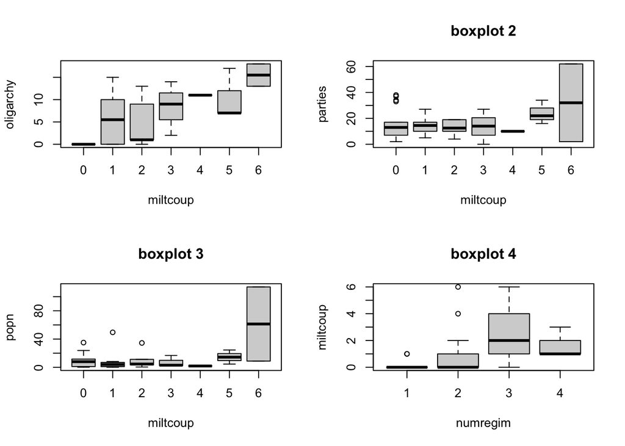

Figure 2: Scatterplot matrix illustrating relationships among all predictors.

```
## [1] "Look for dependency"
```

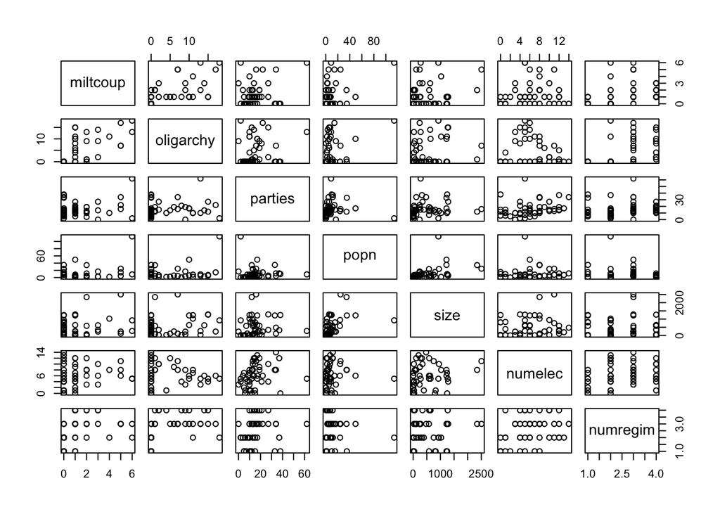

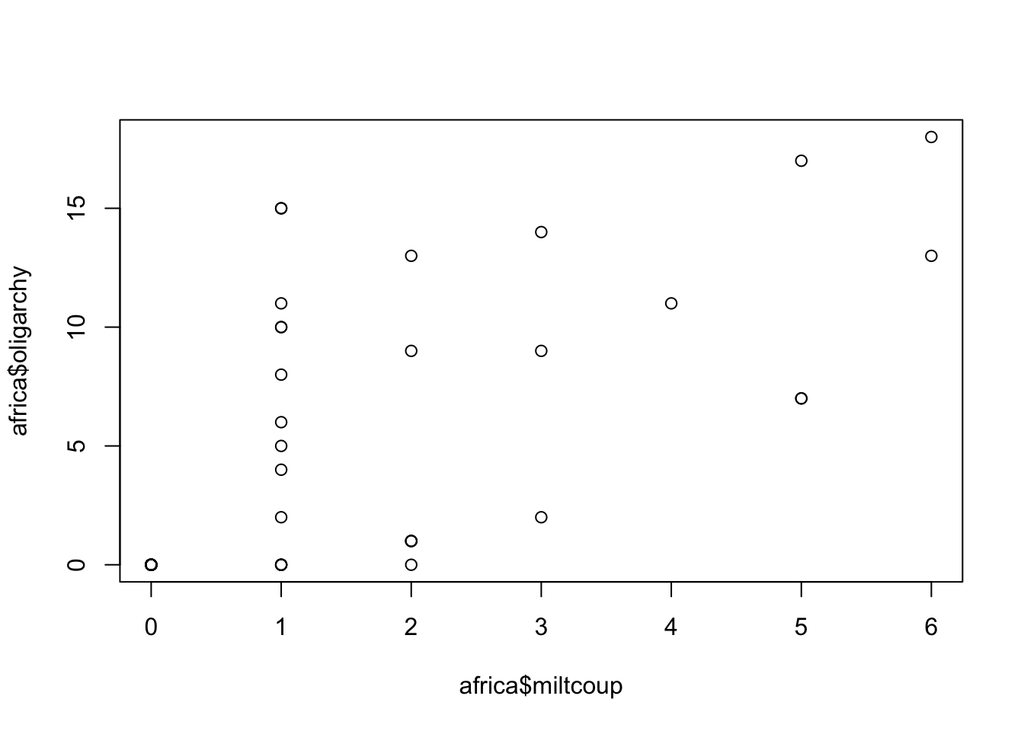

# Finding the disitribution

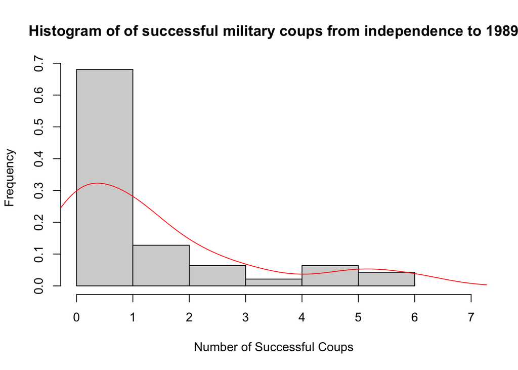

# Building six different models with poisson as distribution with one predictor

I fitted six Poisson regression models to predict the number of military coups (miltcoup) using a single predictor each. Both years under military oligarchy and number of regime types were strong positive predictors, indicating that countries with longer military rule or more regime changes tend to experience more coups. Population also had a small positive effect. In contrast, country size, number of elections, and number of parties were weaker or non-significant predictors. Overall, oligarchy and regime variability are the most important factors in explaining coup frequency in this dataset.

```r
'Create 6 possible models with one predictor only'
```

```
## [1] "Create 6 possible models with one predictor only"
```

```r
mdl<-glm(miltcoup~oligarchy,family=poisson,data=africa)
mdl2<-glm(miltcoup~parties,family=poisson,data=africa)
mdl3<-glm(miltcoup~popn,family=poisson,data=africa)
mdl4<-glm(miltcoup~size,family=poisson,data=africa)
mdl5<-glm(miltcoup~numelec,family=poisson,data=africa)
mdl6<-glm(miltcoup~numregim,family=poisson,data=africa)

'look at the result from the models'
```

```
## [1] "look at the result from the models"
```

```r
summary(mdl)  #**
```

```
##
## Call:
## glm(formula = miltcoup ~ oligarchy, family = poisson, data = africa)
##
## Coefficients:
##             Estimate Std. Error z value Pr(>|z|)
## (Intercept) -0.44280    0.21321  -2.077   0.0378 *
## oligarchy    0.11761    0.01928   6.100 1.06e-09 ***
## ---
## Signif. codes:  0 '***' 0.001 '**' 0.01 '*' 0.05 '.' 0.1 ' ' 1
##
## (Dispersion parameter for poisson family taken to be 1)
##
##     Null deviance: 93.971  on 46  degrees of freedom
## Residual deviance: 57.048  on 45  degrees of freedom
## AIC: 134.73
##
## Number of Fisher Scoring iterations: 5
```

```r
summary(mdl2) #
```

```
##
## Call:
## glm(formula = miltcoup ~ parties, family = poisson, data = africa)
##
## Coefficients:
##              Estimate Std. Error z value Pr(>|z|)
## (Intercept) -0.011277   0.209106  -0.054   0.9570
## parties      0.020109   0.008827   2.278   0.0227 *
## ---
## Signif. codes:  0 '***' 0.001 '**' 0.01 '*' 0.05 '.' 0.1 ' ' 1
##
## (Dispersion parameter for poisson family taken to be 1)
##
##     Null deviance: 93.971  on 46  degrees of freedom
## Residual deviance: 89.439  on 45  degrees of freedom
## AIC: 167.12
##
## Number of Fisher Scoring iterations: 5
```

```r
summary(mdl3) #*
```

```
##
## Call:
## glm(formula = miltcoup ~ popn, family = poisson, data = africa)
##
## Coefficients:
##             Estimate Std. Error z value Pr(>|z|)
## (Intercept) 0.148349   0.144608   1.026 0.304952
## popn        0.013441   0.004036   3.330 0.000868 ***
## ---
## Signif. codes:  0 '***' 0.001 '**' 0.01 '*' 0.05 '.' 0.1 ' ' 1
##
## (Dispersion parameter for poisson family taken to be 1)
##
##     Null deviance: 93.971  on 46  degrees of freedom
## Residual deviance: 85.841  on 45  degrees of freedom
## AIC: 163.52
##
## Number of Fisher Scoring iterations: 5
```

```r
summary(mdl4)
```

```
##
## Call:
## glm(formula = miltcoup ~ size, family = poisson, data = africa)
##
## Coefficients:
##              Estimate Std. Error z value Pr(>|z|)
## (Intercept) 0.1699532  0.1695902   1.002    0.316
## size        0.0002963  0.0001844   1.607    0.108
##
## (Dispersion parameter for poisson family taken to be 1)
##
##     Null deviance: 93.971  on 46  degrees of freedom
## Residual deviance: 91.600  on 45  degrees of freedom
## AIC: 169.28
##
## Number of Fisher Scoring iterations: 5
```

```r
summary(mdl5)
```

```
##
## Call:
## glm(formula = miltcoup ~ numelec, family = poisson, data = africa)
##
## Coefficients:
##             Estimate Std. Error z value Pr(>|z|)
## (Intercept)  0.08478    0.24908   0.340    0.734
## numelec      0.03930    0.03197   1.229    0.219
##
## (Dispersion parameter for poisson family taken to be 1)
##
##     Null deviance: 93.971  on 46  degrees of freedom
## Residual deviance: 92.462  on 45  degrees of freedom
## AIC: 170.14
##
## Number of Fisher Scoring iterations: 5
```

```r
summary(mdl6) #**
```

```
##
## Call:
## glm(formula = miltcoup ~ numregim, family = poisson, data = africa)
##
## Coefficients:
##             Estimate Std. Error z value Pr(>|z|)
## (Intercept)  -0.9093     0.4030  -2.256 0.024045 *
## numregim      0.4563     0.1299   3.513 0.000443 ***
## ---
## Signif. codes:  0 '***' 0.001 '**' 0.01 '*' 0.05 '.' 0.1 ' ' 1
##
## (Dispersion parameter for poisson family taken to be 1)
##
##     Null deviance: 93.971  on 46  degrees of freedom
## Residual deviance: 80.878  on 45  degrees of freedom
## AIC: 158.56
##
## Number of Fisher Scoring iterations: 6
```

# plot the residuals

```
## [1] "plot the residuals"
```

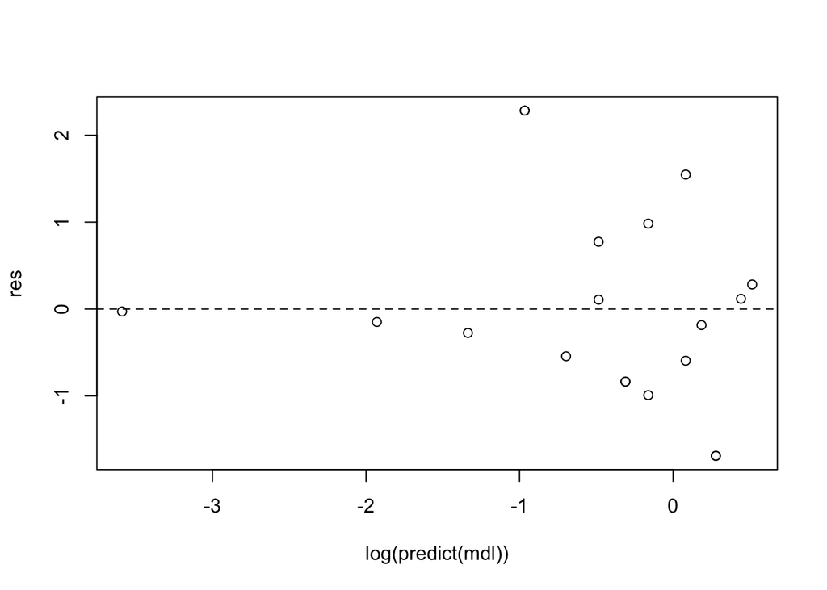

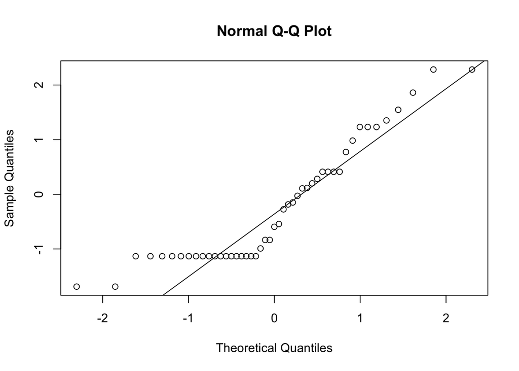

# Check for dispersion

```r
'Check model fit'
```

```
## [1] "Check model fit"
```

```r
1-pchisq(mdl2$deviance,mdl$df.residual) # we can reject H0 that our model fits
```

```
## [1] 9.055872e-05
```

```r
1-pchisq(mdl3$deviance,mdl$df.residual) # we can reject H0 that our model fits
```

```
## [1] 0.0002342715
```

```r
1-pchisq(mdl4$deviance,mdl$df.residual) # we can reject H0 that our model fits
```

```
## [1] 5.039898e-05
```

```r
1-pchisq(mdl5$deviance,mdl$df.residual) # we can reject H0 that our model fits
```

```
## [1] 3.977248e-05
```

```r
1-pchisq(mdl6$deviance,mdl$df.residual) # we can reject H0 that our model fits
```

```
## [1] 0.0008219071
```

```r
# We can apply a significance test directly on the fitted model to heck overdispersion
dispersiontest(mdl)  # fail to reject h0 that is equidispersion
```

```
##
##  Overdispersion test
##
## data:  mdl
## z = 1.2802, p-value = 0.1002
## alternative hypothesis: true dispersion is greater than 1
## sample estimates:
## dispersion
##   1.256082
```

```r
dispersiontest(mdl2) # reject h0 that is equidispersion
```

```
##
##  Overdispersion test
##
## data:  mdl2
## z = 2.1002, p-value = 0.01785
## alternative hypothesis: true dispersion is greater than 1
## sample estimates:
## dispersion
##   1.920386
```

```r
dispersiontest(mdl3) # reject h0 that is equidispersion
```

```
##
##  Overdispersion test
##
## data:  mdl3
## z = 2.2836, p-value = 0.0112
## alternative hypothesis: true dispersion is greater than 1
## sample estimates:
## dispersion
##     1.8249
```

```r
dispersiontest(mdl4) # reject h0 that is equidispersion
```

```
##
##  Overdispersion test
##
## data:  mdl4
## z = 2.4764, p-value = 0.006635
## alternative hypothesis: true dispersion is greater than 1
## sample estimates:
## dispersion
##   1.990645
```

```r
dispersiontest(mdl5) # reject h0 that is equidispersion
```

```
##
##  Overdispersion test
##
## data:  mdl5
## z = 2.5229, p-value = 0.00582
## alternative hypothesis: true dispersion is greater than 1
## sample estimates:
## dispersion
##   2.030384
```

```r
dispersiontest(mdl6) # reject h0 that is equidispersion
```

```
##
##  Overdispersion test
##
## data:  mdl6
## z = 2.1731, p-value = 0.01489
## alternative hypothesis: true dispersion is greater than 1
## sample estimates:
## dispersion
##   2.035983
```

# Outliers check

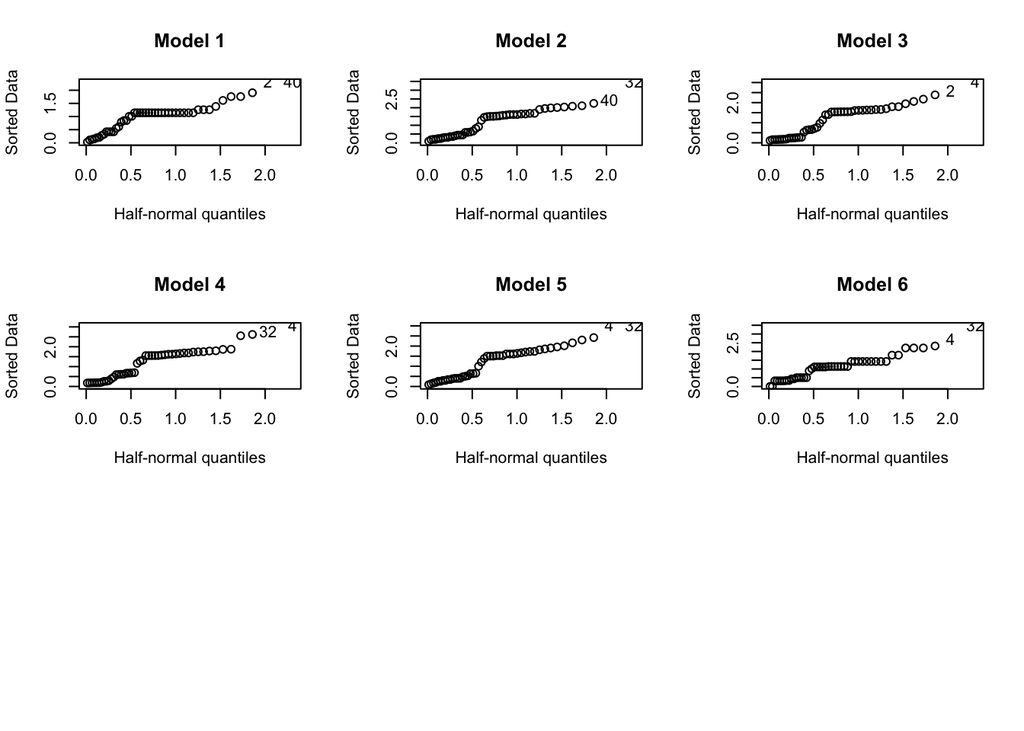

```r
par(mfrow=c(3,3))
halfnorm(rstudent(mdl),main="Model 1")  # no evidence of outstanding outliers
halfnorm(rstudent(mdl2), main="Model 2")  # no evidence of outstanding outliers
halfnorm(rstudent(mdl3), main="Model 3")  # no evidence of outstanding outliers
halfnorm(rstudent(mdl4), main="Model 4")  # no evidence of outstanding outliers
halfnorm(rstudent(mdl5), main="Model 5")  # no evidence of outstanding outliers
halfnorm(rstudent(mdl6), main="Model 6")  # no evidence of outstanding outliers
```

# Checking model assumption-if mean is equal to variance

```r
par(mfrow=c(2,3))
E_hat=predict(mdl,type="response")
V_hat=(africa$miltcoup-E_hat)^2  #(y-v_hat)^2
plot(log(E_hat),log(V_hat), main="Model 1")
abline(0,1)
'mdl2'
```

```
## [1] "mdl2"
```

```r
E_hat=predict(mdl2,type="response")
V_hat=(africa$miltcoup-E_hat)^2  #(y-v_hat)^2
plot(log(E_hat),log(V_hat), main="Model 2")
abline(0,1)   #"variance = mean" line#
'mdl3'
```

```
## [1] "mdl3"
```

```r
E_hat=predict(mdl3,type="response")
V_hat=(africa$miltcoup-E_hat)^2  #(y-v_hat)^2
plot(log(E_hat),log(V_hat), main="Model 3")
abline(0,1)   #"variance = mean" line#
'mdl4'
```

```
## [1] "mdl4"
```

```r
E_hat=predict(mdl4,type="response")
V_hat=(africa$miltcoup-E_hat)^2  #(y-v_hat)^2
plot(log(E_hat),log(V_hat), main="Model 4")
abline(0,1)   #"variance = mean" line#
'mdl5'
```

```
## [1] "mdl5"
```

```r
E_hat=predict(mdl5,type="response")
V_hat=(africa$miltcoup-E_hat)^2  #(y-v_hat)^2
plot(log(E_hat),log(V_hat), main="Model 5")
abline(0,1)   #"variance = mean" line#
'mdl6'
```

```
## [1] "mdl6"
```

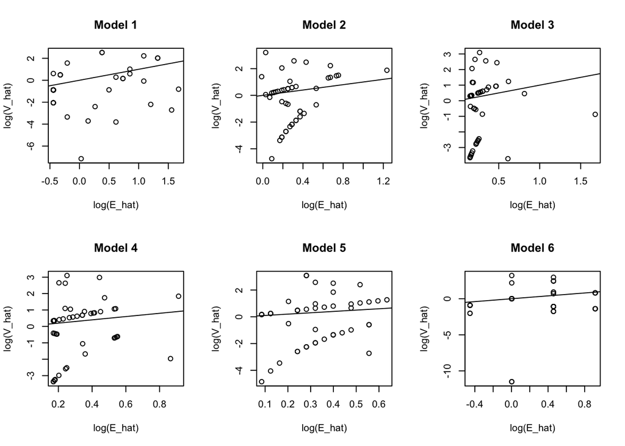

```r
E_hat=predict(mdl6,type="response")
V_hat=(africa$miltcoup-E_hat)^2  #(y-v_hat)^2
plot(log(E_hat),log(V_hat),main="Model 6")
abline(0,1)   #"variance = mean" line#
```

# Model containing all predictors

A full Poisson regression model shows that years under military oligarchy is the strongest predictor of military coups, while other variables (parties, population, size, elections, regime types) are not significant. The model fits well (residual deviance = 48.5, AIC = 136.2) and there is no overdispersion (dispersion ≈ 1.01). Comparing AIC values confirms that oligarchy alone explains most of the variation in coup counts.

```r
mdlFULL<-glm(miltcoup~.,family=poisson,data=africa)
summary(mdlFULL) #* oligarchy and intercept is significant
```

```
##
## Call:
## glm(formula = miltcoup ~ ., family = poisson, data = africa)
##
## Coefficients:
##               Estimate Std. Error z value Pr(>|z|)
## (Intercept) -1.7727472  0.6322747  -2.804  0.00505 **
## oligarchy    0.1126402  0.0285698   3.943 8.06e-05 ***
## parties      0.0126926  0.0094111   1.349  0.17744
## popn         0.0061010  0.0056580   1.078  0.28090
## size        -0.0000377  0.0002241  -0.168  0.86637
## numelec      0.0855420  0.0486688   1.758  0.07881 .
## numregim     0.1780261  0.1850845   0.962  0.33612
## ---
## Signif. codes:  0 '***' 0.001 '**' 0.01 '*' 0.05 '.' 0.1 ' ' 1
##
## (Dispersion parameter for poisson family taken to be 1)
##
##     Null deviance: 93.971  on 46  degrees of freedom
## Residual deviance: 48.535  on 40  degrees of freedom
## AIC: 136.22
##
## Number of Fisher Scoring iterations: 6
```

```r
1-pchisq(mdlFULL$deviance,mdlFULL$df.residual) #the model fits the data
```

```
## [1] 0.1667289
```

```r
dispersiontest(mdlFULL)
```

```
##
##  Overdispersion test
##
## data:  mdlFULL
## z = 0.094431, p-value = 0.4624
## alternative hypothesis: true dispersion is greater than 1
## sample estimates:
## dispersion
##   1.012758
```

```r
'comparing'
```

```
## [1] "comparing"
```

```r
AIC(mdlFULL)
```

```
## [1] 136.2156
```

```r
AIC(mdl)
```

```
## [1] 134.7279
```

```r
AIC(mdl2)
```

```
## [1] 167.1194
```

```r
AIC(mdl3)
```

```
## [1] 163.5214
```

```r
AIC(mdl4)
```

```
## [1] 169.2801
```

```r
AIC(mdl5)
```

```
## [1] 170.1419
```

```r
AIC(mdl6)
```

```
## [1] 158.5581
```